# HW1

Nathan Krieger

2026-01-26

# Problem 1

```r
auto <- read.table("Auto.data", header = TRUE, na.strings = "?")
```

## (a)

```r
nrow(auto)
```

```
## [1] 397
```

```r
ncol(auto)
```

```
## [1] 9
```

- There are 397 rows and 9 columns.

## (b)

```r
auto_clean <- drop_na(auto)

nrow(auto_clean)
```

```
## [1] 392
```

```r
ncol(auto_clean)
```

```
## [1] 9
```

- After cleaning, it dropped 5 observations.

## (c)

```r
str(auto_clean)
```

```
## 'data.frame':    392 obs. of  9 variables:
##  $ mpg         : num  18 15 18 16 17 15 14 14 14 15 ...
##  $ cylinders   : int  8 8 8 8 8 8 8 8 8 8 ...
##  $ displacement: num  307 350 318 304 302 429 454 440 455 390 ...
##  $ horsepower  : num  130 165 150 150 140 198 220 215 225 190 ...
##  $ weight      : num  3504 3693 3436 3433 3449 ...
##  $ acceleration: num  12 11.5 11 12 10.5 10 9 8.5 10 8.5 ...
##  $ year        : int  70 70 70 70 70 70 70 70 70 70 ...
##  $ origin      : int  1 1 1 1 1 1 1 1 1 1 ...
##  $ name        : chr  "chevrolet chevelle malibu" "buick skylark 320" "plymouth satellite" "amc rebel sst" ...
```

## (d)

```r
# auto_clean
```

- No because there are too many names for vehicles. Also, storing name as a factor doesn’t help prediction as much as HP or other variables.

## (e)

```r
head(auto_clean, 10)
```

```
##    mpg cylinders displacement horsepower weight acceleration year origin
## 1   18         8          307        130   3504         12.0   70      1
## 2   15         8          350        165   3693         11.5   70      1
## 3   18         8          318        150   3436         11.0   70      1
## 4   16         8          304        150   3433         12.0   70      1
## 5   17         8          302        140   3449         10.5   70      1
## 6   15         8          429        198   4341         10.0   70      1
## 7   14         8          454        220   4354          9.0   70      1
## 8   14         8          440        215   4312          8.5   70      1
## 9   14         8          455        225   4425         10.0   70      1
## 10  15         8          390        190   3850          8.5   70      1
##                         name
## 1  chevrolet chevelle malibu
## 2          buick skylark 320
## 3         plymouth satellite
## 4              amc rebel sst
## 5                ford torino
## 6           ford galaxie 500
## 7           chevrolet impala
## 8          plymouth fury iii
## 9           pontiac catalina
## 10        amc ambassador dpl
```

- head(auto_clean, 10)

## (f)

```r
auto_clean[c(10, 14, 29), ]
```

```
##    mpg cylinders displacement horsepower weight acceleration year origin
## 10  15         8          390        190   3850          8.5   70      1
## 14  14         8          455        225   3086         10.0   70      1
## 29   9         8          304        193   4732         18.5   70      1
##                       name
## 10      amc ambassador dpl
## 14 buick estate wagon (sw)
## 29                hi 1200d
```

## (g)

```r
auto_clean[c(10, 14, 29), c("displacement", "horsepower")]
```

```
##    displacement horsepower
## 10          390        190
## 14          455        225
## 29          304        193
```

## (h)

```r
mean(auto_clean$mpg[auto_clean$horsepower < 200])
```

```
## [1] 23.75801
```

- 23.75801

## (i)

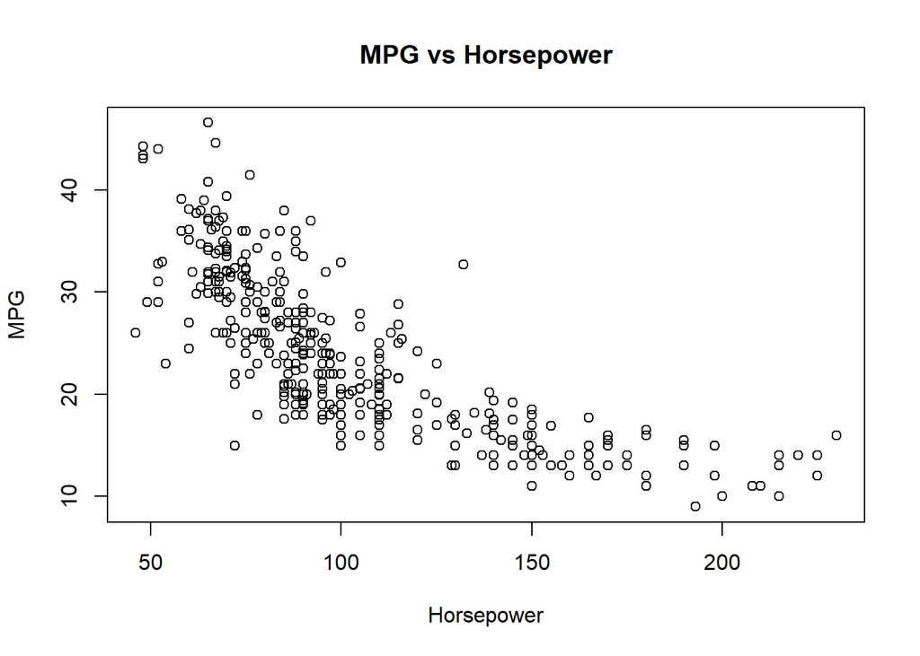

```r
plot(auto_clean$horsepower, auto_clean$mpg,
xlab = "Horsepower", ylab = "MPG",
main = "MPG vs Horsepower")
```

## (j)

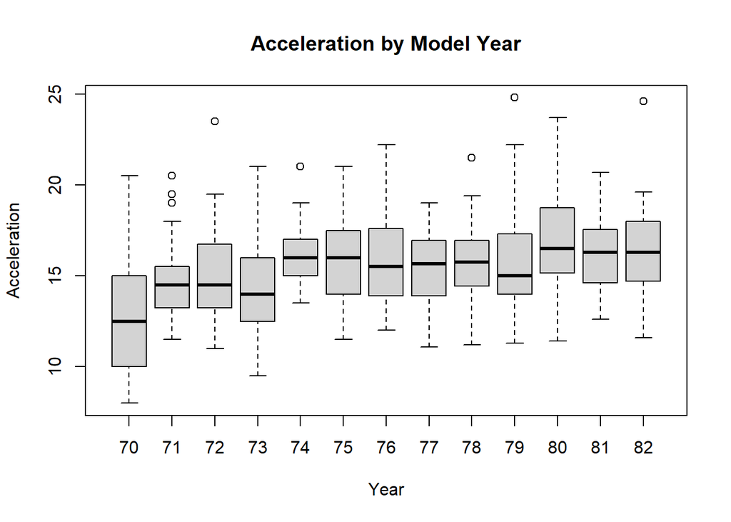

```r
boxplot(acceleration ~ year, data = auto_clean,
xlab = "Year", ylab = "Acceleration",
main = "Acceleration by Model Year")
```

## (k)

- Vectorized means you can give a function a whole list of numbers at once, and it will automatically do the calculation on each value, without you having to repeat the instruction. It’s like using a specialized stamp that hits every row at once instead of writing on them one by one with a pen. It makes the code much faster and easier to read.

# Problem 2

```r
# install.packages("ISLR2")
library(ISLR2)
head(Boston)
```

```
##      crim zn indus chas   nox    rm  age    dis rad tax ptratio lstat medv
## 1 0.00632 18  2.31    0 0.538 6.575 65.2 4.0900   1 296    15.3  4.98 24.0
## 2 0.02731  0  7.07    0 0.469 6.421 78.9 4.9671   2 242    17.8  9.14 21.6
## 3 0.02729  0  7.07    0 0.469 7.185 61.1 4.9671   2 242    17.8  4.03 34.7
## 4 0.03237  0  2.18    0 0.458 6.998 45.8 6.0622   3 222    18.7  2.94 33.4
## 5 0.06905  0  2.18    0 0.458 7.147 54.2 6.0622   3 222    18.7  5.33 36.2
## 6 0.02985  0  2.18    0 0.458 6.430 58.7 6.0622   3 222    18.7  5.21 28.7
```

## (a)

```r
nrow(Boston)
```

```
## [1] 506
```

```r
ncol(Boston)
```

```
## [1] 13
```

- There are 506 rows and 13 columns

## (b)

```r
 # ?Boston
```

- lower status of the population (percent).

## (c)

```r
mean(Boston$crim)
```

```
## [1] 3.613524
```

- 3.613524

## (d)

```r
mean(Boston$crim[Boston$chas == 0])
```

```
## [1] 3.744447
```

```r
mean(Boston$crim[Boston$chas == 1])
```

```
## [1] 1.85167
```

## (e)

```r
summary(Boston$crim)
```

```
##     Min.  1st Qu.   Median     Mean  3rd Qu.     Max.
##  0.00632  0.08205  0.25651  3.61352  3.67708 88.97620
```

```r
Boston[Boston$crim > quantile(Boston$crim, 0.75), ]
```

```
##         crim zn indus chas   nox    rm   age    dis rad tax ptratio lstat medv
## 144  4.09740  0 19.58    0 0.871 5.468 100.0 1.4118   5 403    14.7 26.42 15.6
## 357  8.98296  0 18.10    1 0.770 6.212  97.4 2.1222  24 666    20.2 17.60 17.8
## 358  3.84970  0 18.10    1 0.770 6.395  91.0 2.5052  24 666    20.2 13.27 21.7
## 359  5.20177  0 18.10    1 0.770 6.127  83.4 2.7227  24 666    20.2 11.48 22.7
## 360  4.26131  0 18.10    0 0.770 6.112  81.3 2.5091  24 666    20.2 12.67 22.6
## 361  4.54192  0 18.10    0 0.770 6.398  88.0 2.5182  24 666    20.2  7.79 25.0
## 362  3.83684  0 18.10    0 0.770 6.251  91.1 2.2955  24 666    20.2 14.19 19.9
## 363  3.67822  0 18.10    0 0.770 5.362  96.2 2.1036  24 666    20.2 10.19 20.8
## 364  4.22239  0 18.10    1 0.770 5.803  89.0 1.9047  24 666    20.2 14.64 16.8
## 366  4.55587  0 18.10    0 0.718 3.561  87.9 1.6132  24 666    20.2  7.12 27.5
## 367  3.69695  0 18.10    0 0.718 4.963  91.4 1.7523  24 666    20.2 14.00 21.9
## 368 13.52220  0 18.10    0 0.631 3.863 100.0 1.5106  24 666    20.2 13.33 23.1
## 369  4.89822  0 18.10    0 0.631 4.970 100.0 1.3325  24 666    20.2  3.26 50.0
## 370  5.66998  0 18.10    1 0.631 6.683  96.8 1.3567  24 666    20.2  3.73 50.0
```

[output cut: 113 more lines]

```r
Boston[Boston$crim >= quantile(Boston$crim, 0.98), ]
```

```
##        crim zn indus chas   nox    rm   age    dis rad tax ptratio lstat medv
## 381 88.9762  0  18.1    0 0.671 6.968  91.9 1.4165  24 666    20.2 17.21 10.4
## 399 38.3518  0  18.1    0 0.693 5.453 100.0 1.4896  24 666    20.2 30.59  5.0
## 401 25.0461  0  18.1    0 0.693 5.987 100.0 1.5888  24 666    20.2 26.77  5.6
## 405 41.5292  0  18.1    0 0.693 5.531  85.4 1.6074  24 666    20.2 27.38  8.5
## 406 67.9208  0  18.1    0 0.693 5.683 100.0 1.4254  24 666    20.2 22.98  5.0
## 411 51.1358  0  18.1    0 0.597 5.757 100.0 1.4130  24 666    20.2 10.11 15.0
## 414 28.6558  0  18.1    0 0.597 5.155 100.0 1.5894  24 666    20.2 20.08 16.3
## 415 45.7461  0  18.1    0 0.693 4.519 100.0 1.6582  24 666    20.2 36.98  7.0
## 418 25.9406  0  18.1    0 0.679 5.304  89.1 1.6475  24 666    20.2 26.64 10.4
## 419 73.5341  0  18.1    0 0.679 5.957 100.0 1.8026  24 666    20.2 20.62  8.8
## 428 37.6619  0  18.1    0 0.679 6.202  78.7 1.8629  24 666    20.2 14.52 10.9
```

## (f)

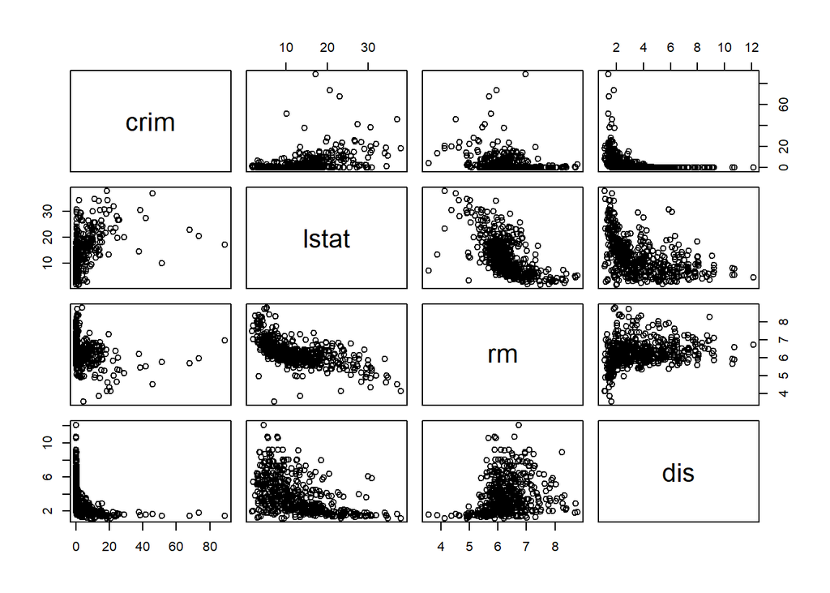

```r
pairs(Boston[, c("crim", "lstat", "rm", "dis")])
```

```r
r_vals <- sapply(Boston[, -which(names(Boston) == "crim")],
                 function(x) cor(x, Boston$crim))

r_vals
```

```
##          zn       indus        chas         nox          rm         age
## -0.20046922  0.40658341 -0.05589158  0.42097171 -0.21924670  0.35273425
##         dis         rad         tax     ptratio       lstat        medv
## -0.37967009  0.62550515  0.58276431  0.28994558  0.45562148 -0.38830461
```

- Using pairs, I see correlations in several areas. I also looked at all the correlation values, based on this, nox, rad, tax, and lstat have particularly high correlations. This is interesting because nox is the nitrogen oxide concentration. This is a good example of correlation not equalling causation.

## (g)

```r
model_simple <- lm(crim ~ lstat, data = Boston)
summary(model_simple)
```

```
##
## Call:
## lm(formula = crim ~ lstat, data = Boston)
##
## Residuals:
##     Min      1Q  Median      3Q     Max
## -13.925  -2.822  -0.664   1.079  82.862
##
## Coefficients:
##             Estimate Std. Error t value Pr(>|t|)
## (Intercept) -3.33054    0.69376  -4.801 2.09e-06 ***
## lstat        0.54880    0.04776  11.491  < 2e-16 ***
## ---
## Signif. codes:  0 '***' 0.001 '**' 0.01 '*' 0.05 '.' 0.1 ' ' 1
##
## Residual standard error: 7.664 on 504 degrees of freedom
## Multiple R-squared:  0.2076, Adjusted R-squared:  0.206
## F-statistic:   132 on 1 and 504 DF,  p-value: < 2.2e-16
```

- Intercept coef = -3.33
- Slope coef = 0.55
- Based on these results it’s clear that there is a significant correlation between lstat and crime rate.

## (h)

```r
predictors <- setdiff(names(Boston), "crim")

results_list <- lapply(predictors, function(var) {
  fit <- lm(as.formula(paste("crim ~", var)), data = Boston)

  data.frame(
    variable = var,
    estimate = coef(summary(fit))[2, 1],
    p_value = coef(summary(fit))[2, 4]
  )
})

simple_results_df <- do.call(rbind, results_list)
print(simple_results_df)
```

```
##    variable    estimate      p_value
## 1        zn -0.07393498 5.506472e-06
## 2     indus  0.50977633 1.450349e-21
## 3      chas -1.89277655 2.094345e-01
## 4       nox 31.24853120 3.751739e-23
## 5        rm -2.68405122 6.346703e-07
## 6       age  0.10778623 2.854869e-16
## 7       dis -1.55090168 8.519949e-19
## 8       rad  0.61791093 2.693844e-56
## 9       tax  0.02974225 2.357127e-47
## 10  ptratio  1.15198279 2.942922e-11
## 11    lstat  0.54880478 2.654277e-27
## 12     medv -0.36315992 1.173987e-19
```

- Positive correlation: indus, nox, age, rad, tax, ptratio, lstat
- Negative correlation: zn, rm, dis, medv
- Statistically significant predictors: using the 5% significance level, all predictors other than chas show significance.
- Plots:

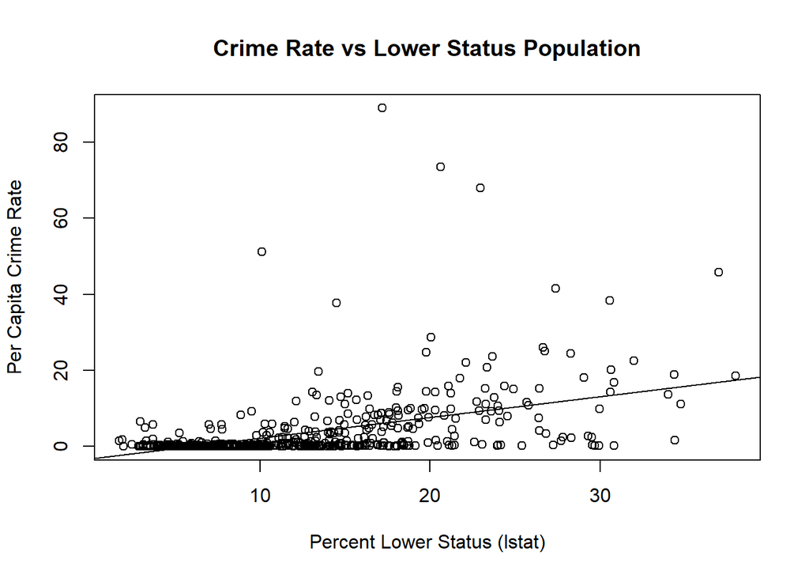

```r
plot(Boston$lstat, Boston$crim,
     xlab = "Percent Lower Status (lstat)",
     ylab = "Per Capita Crime Rate",
     main = "Crime Rate vs Lower Status Population")
abline(lm(crim ~ lstat, data = Boston))
```

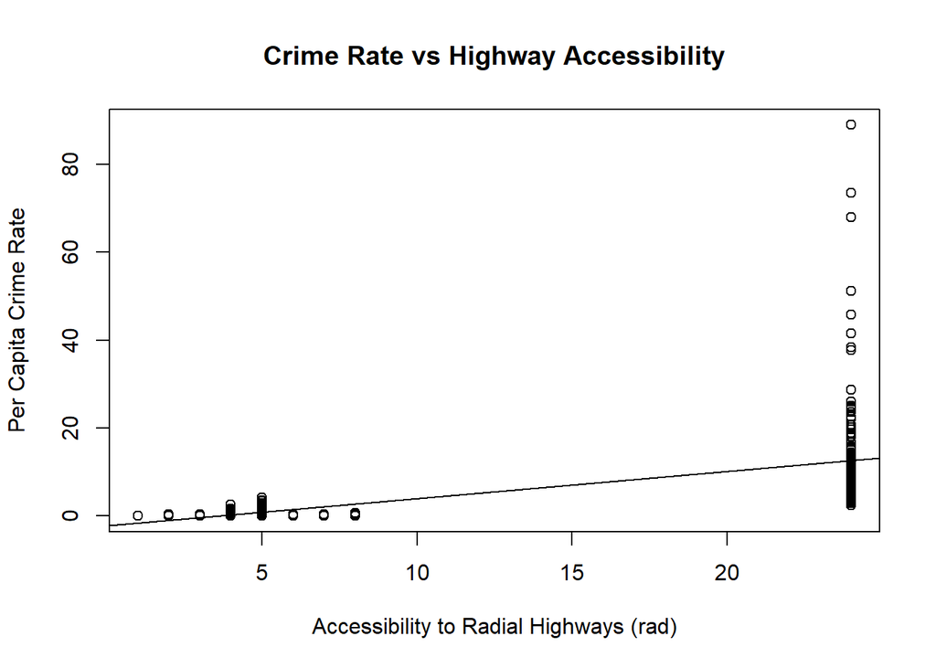

```r
plot(Boston$rad, Boston$crim,
     xlab = "Accessibility to Radial Highways (rad)",
     ylab = "Per Capita Crime Rate",
     main = "Crime Rate vs Highway Accessibility")
abline(lm(crim ~ rad, data = Boston))
```

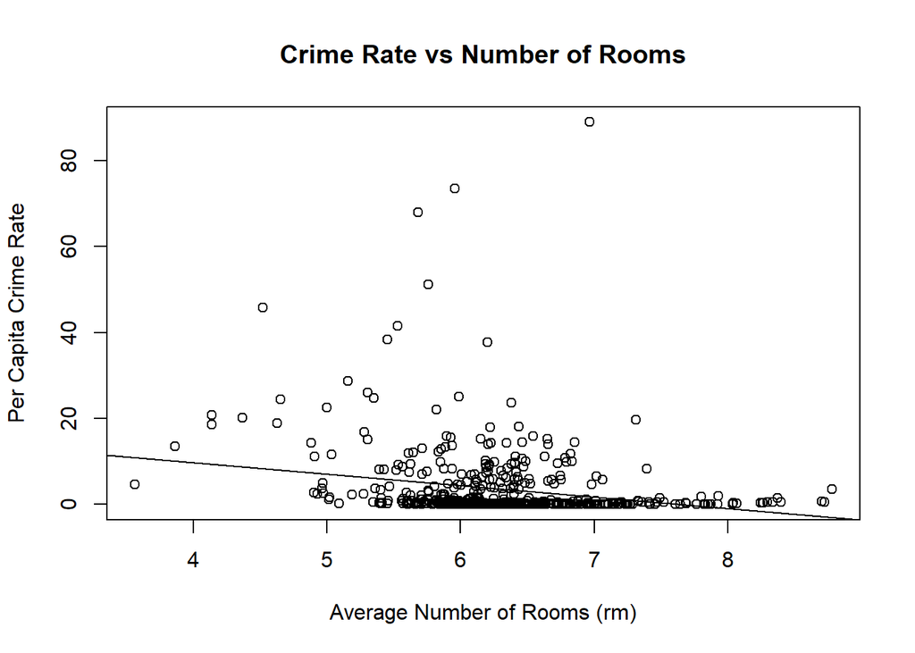

```r
plot(Boston$rm, Boston$crim,
     xlab = "Average Number of Rooms (rm)",
     ylab = "Per Capita Crime Rate",
     main = "Crime Rate vs Number of Rooms")
abline(lm(crim ~ rm, data = Boston))
```

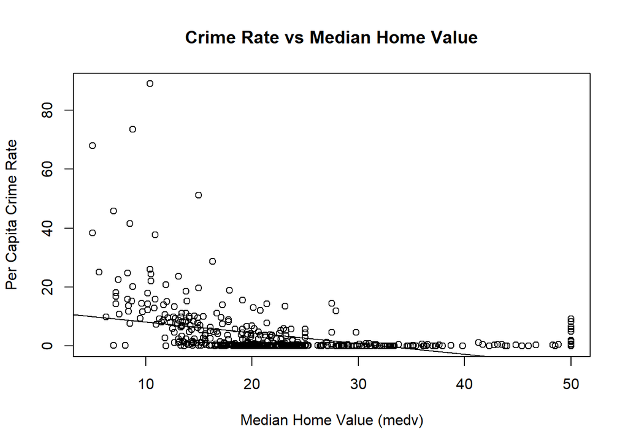

```r
plot(Boston$medv, Boston$crim,
     xlab = "Median Home Value (medv)",
     ylab = "Per Capita Crime Rate",
     main = "Crime Rate vs Median Home Value")
abline(lm(crim ~ medv, data = Boston))
```

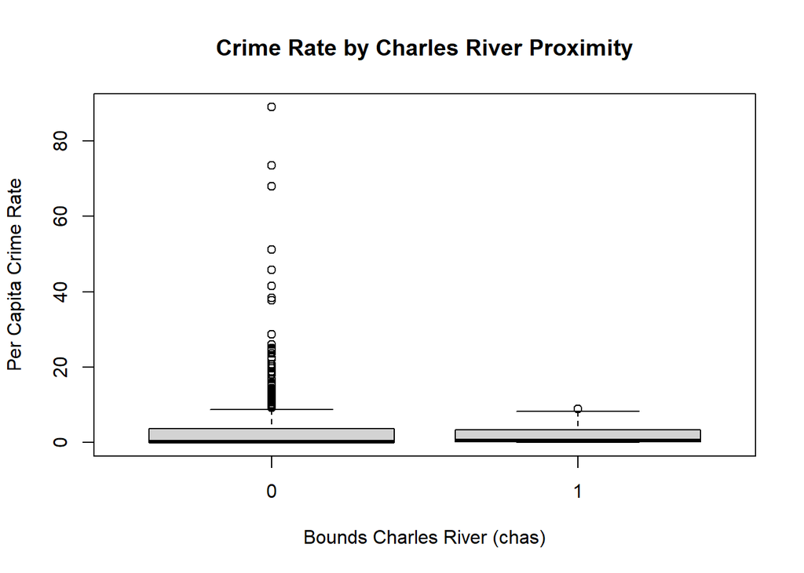

```r
boxplot(crim ~ chas, data = Boston,
        xlab = "Bounds Charles River (chas)",
        ylab = "Per Capita Crime Rate",
        main = "Crime Rate by Charles River Proximity")
```

## (i)

```r
model_multi <- lm(crim ~ ., data = Boston)

multi_table <- as.data.frame(summary(model_multi)$coefficients)

colnames(multi_table) <- c("Estimate", "Std. Error", "t value", "Pr(>|t|)")

round(multi_table, 4)
```

```
##             Estimate Std. Error t value Pr(>|t|)
## (Intercept)  13.7784     7.0818  1.9456   0.0523
## zn            0.0457     0.0188  2.4326   0.0153
## indus        -0.0584     0.0836 -0.6977   0.4857
## chas         -0.8254     1.1834 -0.6975   0.4858
## nox          -9.9576     5.2898 -1.8824   0.0604
## rm            0.6289     0.6071  1.0359   0.3007
## age          -0.0008     0.0179 -0.0473   0.9623
## dis          -1.0122     0.2825 -3.5836   0.0004
## rad           0.6125     0.0875  6.9967   0.0000
## tax          -0.0038     0.0052 -0.7300   0.4658
## ptratio      -0.3041     0.1864 -1.6316   0.1034
## lstat         0.1388     0.0757  1.8330   0.0674
## medv         -0.2201     0.0598 -3.6784   0.0003
```

- Results shown in the output table above.

## (j)

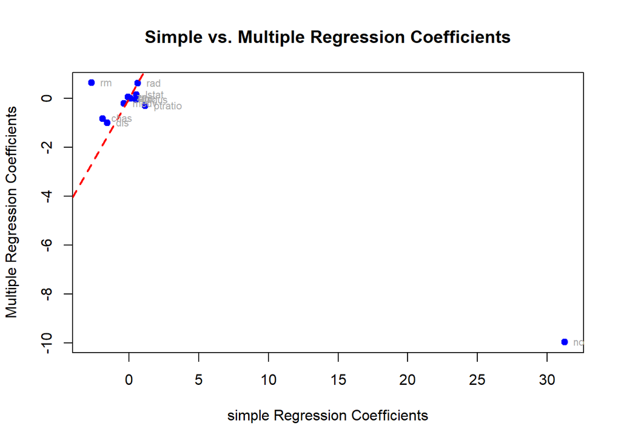

```r
simple_coeffs <- simple_results_df$estimate
multi_coeffs <- coef(model_multi)[-1]

plot(simple_coeffs, multi_coeffs,
     pch = 19, col = "blue",
     xlab = "simple Regression Coefficients",
     ylab = "Multiple Regression Coefficients",
     main = "Simple vs. Multiple Regression Coefficients")

abline(0, 1, col = "red", lwd = 2, lty = 2)

text(simple_coeffs, multi_coeffs, labels = names(multi_coeffs),
     pos = 4, cex = 0.7, col = "darkgray")
```

The graph shows most results land around the 45 degree line. I also see an outlier with a high x and a low y value.

## (k)

- Part J shows us that multiple regression coefficients are superior to a simple regression in this case. For most of the variables, a simple model is good, but nox highlights the weakness of the simple model and is clearly an outlier on the graph. A multiple linear regression model will filter out the results that correlate but do not cause the relationship.

# Problem 3

## (a)

- Answer ii is correct.

We know y = 50 + 20x1 + 0.07x2 + 35x2

If we hold IQ and GPA constant, the only difference in the predicted salary is x2

For a college graduate 35(1) = 35 For a high school graduate 35(0) = 0

So a college graduate will make 35k more than a high school graduate according to this model.

## (b)

- IQ = 110, GPA = 4 y = 50 + 20x1 + 0.07x2 + 35x2

y = 50 + 20(4) + 0.07(110) + 35(1)

y = 50 + 80 + 7.7 + 35 = 172.7 -> $172,700

## (c)

NOTE: The answer to this question depends on what you consider important. Each IQ point represents 70$ a year.

Statistically FALSE: a small coefficient is not inherently unimportant.

We can look at 2 different cases with IQs of 80 and 130, other variables fixed.

GPA = 4, college graduate

y1 = 50 + 20(4) + 0.07(80) + 35(1) y1 = 170.6

y2 = 50 + 20(4) + 0.07(130) + 35(1) y2 = 174.1

Having a 50 point difference in IQ leads to an extra 3.5k in this case which is not an insignificant amount of money. Thus IQ is statistically useful for predicting income.